# Rgames: Week 8 (revised)

Now we will import data directly from the web and play with qqplot/normal probabilty plot

## Import data from the web directly.

First, make sure you have installed *data.table* package. If not, go ahead and install it. Then load data.table package into R. The fread usually works well for reading csv and other standard ascii files.

```r
library(data.table)
exam <- fread('http://faculty.ndhu.edu.tw/~chtsao/ftp/stat2016.txt')
```

```
  % Total    % Received % Xferd  Average Speed   Time    Time     Time  Current
                                 Dload  Upload   Total   Spent    Left  Speed

  0     0    0     0    0     0      0      0 --:--:-- --:--:-- --:--:--     0
100   558  100   558    0     0  10631      0 --:--:-- --:--:-- --:--:-- 10730
```

```r
head(exam)   # Take a quick look of first few cases
```

| V1 | V2 | V3 |
| --- | --- | --- |
| 2 | 5 | 36 |
| 2 | 75 | 63 |
| 2 | 37 | 38 |
| 2 | 27 | 0 |
| 2 | 16 | 14 |
| 2 | 46 | 57 |

fread creates exam which is a dataframe. Assign variable names: year, mid, final. Set year to factor.

```r
summary(exam)
```

```
       V1              V2               V3
 Min.   :2.000   Min.   :  0.00   Min.   :-10.00
 1st Qu.:2.000   1st Qu.: 25.50   1st Qu.: 13.50
 Median :2.000   Median : 46.00   Median : 31.00
 Mean   :2.476   Mean   : 46.52   Mean   : 34.11
 3rd Qu.:3.000   3rd Qu.: 67.50   3rd Qu.: 53.00
 Max.   :5.000   Max.   :110.00   Max.   :100.00
```

```r
is.data.frame(exam)
```

```
[1] TRUE
```

```r
colnames(exam)<-c("year","mid","final")
exam$year<-as.factor(exam$year)
summary(exam)
```

```
 year        mid             final
 2:42   Min.   :  0.00   Min.   :-10.00
 3:15   1st Qu.: 25.50   1st Qu.: 13.50
 4: 3   Median : 46.00   Median : 31.00
 5: 3   Mean   : 46.52   Mean   : 34.11
        3rd Qu.: 67.50   3rd Qu.: 53.00
        Max.   :110.00   Max.   :100.00
```

Now we use ggplot to further explore the data refer to [Data visualization with ggplot2](https://www.mailman.columbia.edu/sites/default/files/media/fdawg_ggplot2.html)

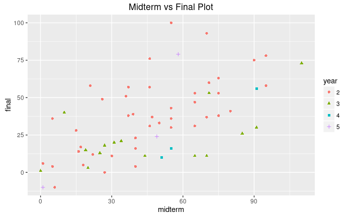

```r
library(ggplot2)
scatter <- ggplot(data=exam, aes(x = mid, y = final))
scatter + geom_point(aes(color=year, shape=year)) +
  xlab("midterm") +  ylab("final") +
  ggtitle("Midterm vs Final Plot")
```

```r
# Construct boxplot of midterm, final (respectively) by year
```

### Motivating Questions (MQ):

- What do you observe? Some motivating questions to ask yourself
- Is there difference between scores (mid, final) of students from different years? For example mid|year=2 vs. mid|year=3
- Breaking the data points by year (scattered plot, boxplots) reveals some patterns

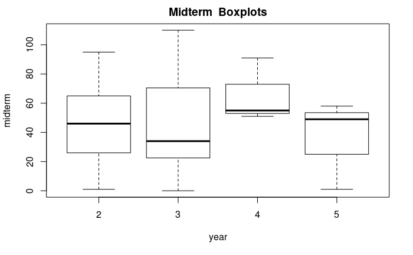

```r
boxplot(mid~year,data=exam,
        xlab="year", ylab="midterm", main="Midterm  Boxplots")
```

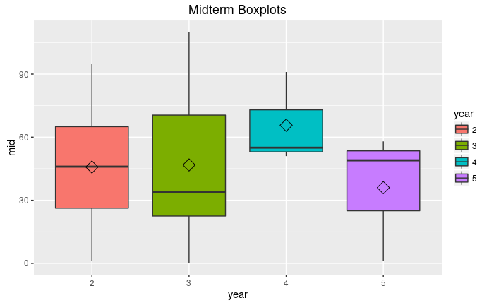

```r
#library(ggplot2)
box <- ggplot(data=exam, aes(x=year, y=mid))
box + geom_boxplot(aes(fill=year)) +
  ylab("mid") + ggtitle("Midterm Boxplots") +
  stat_summary(fun.y=mean, geom="point", shape=5, size=4)
```

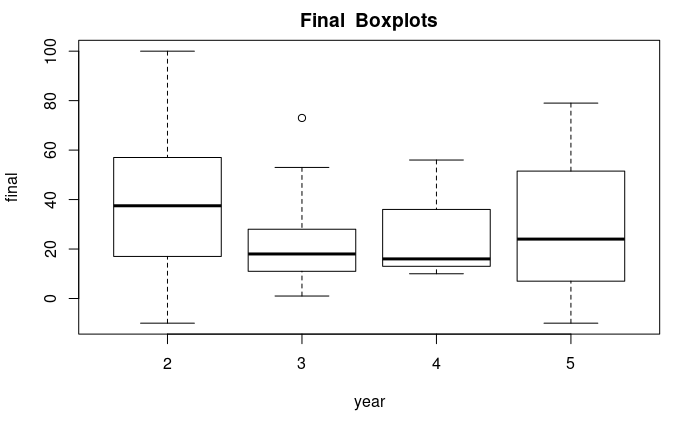

```r
boxplot(final~year,data=exam,
        xlab="year", ylab="final", main="Final  Boxplots")
```

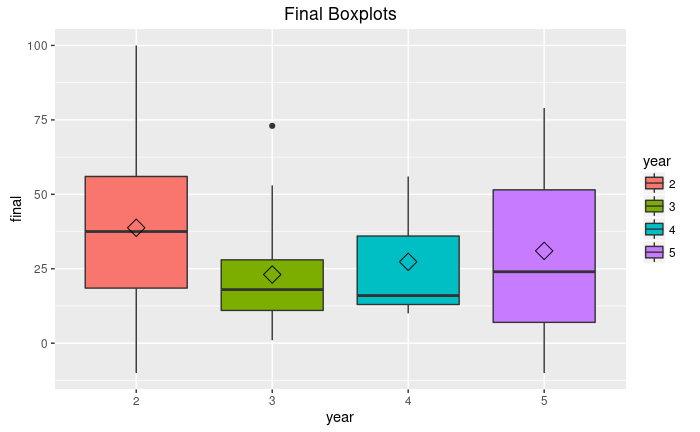

```r
#library(ggplot2)
box <- ggplot(data=exam, aes(x=year, y=final))
box + geom_boxplot(aes(fill=year)) +
  ylab("final") + ggtitle("Final Boxplots") +
  stat_summary(fun.y=mean, geom="point", shape=5, size=4)
```

## Midterm project hints and suggestions

```r
attach(exam)
m2<-lm(final~mid)
summary(m2)
```

```
Call:
lm(formula = final ~ mid)

Residuals:
    Min      1Q  Median      3Q     Max
-36.062 -12.562  -3.029  10.211  61.213

Coefficients:
            Estimate Std. Error t value Pr(>|t|)
(Intercept)  8.44481    5.14339   1.642    0.106
mid          0.55168    0.09554   5.774 2.79e-07 ***
---
Signif. codes:  0 ‘***’ 0.001 ‘**’ 0.01 ‘*’ 0.05 ‘.’ 0.1 ‘ ’ 1

Residual standard error: 20.54 on 61 degrees of freedom
Multiple R-squared:  0.3534,    Adjusted R-squared:  0.3428
F-statistic: 33.34 on 1 and 61 DF,  p-value: 2.791e-07
```

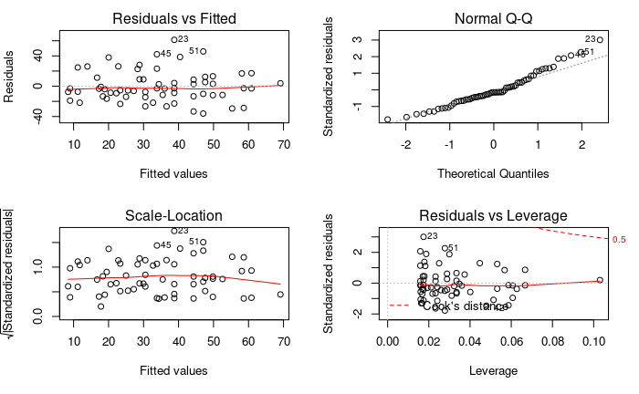

```r
par(mfrow=c(2,2));
plot(m2)
par(mfrow=c(1,1));
```

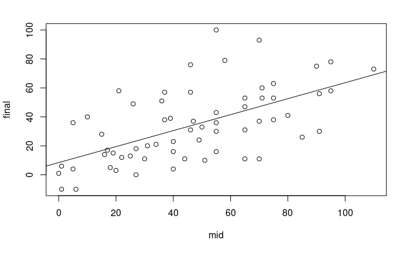

```r
plot(final~mid)
abline(m2)
```

```r
summary(mid); sd(mid)
```

```
   Min. 1st Qu.  Median    Mean 3rd Qu.    Max.
   0.00   25.50   46.00   46.52   67.50  110.00
[1] 27.30228
```

### MQ

- What is the fitted regression line? How can it be used to predict the final score given the midterm score?
- Is it a good fit? Overall and by year?
- Is the prediction good for all mid range?
- What if the distribution of 2017 mid is reasonably normal but with mean=60, sd=16? Say, a student scores 50 points in midterm 2017, what would be her score for midterm 2016?

There are some other alternative ways to download data from the web. See [Getting Data From One Online Source](https://www.r-bloggers.com/getting-data-from-an-online-source/)